# POMP Modeling for COVID-19 in Italy

Ming-Chen Lu, mingchlu@umich.edu

April 29, 2020

## 1. Introduction

Novel Coronavirus disease (COVID-19), an highly contagious disease that can be transmitted through respository droplets and contact transmission, was first discovered in Wuhan City, Hubei Province, China in December 2019 and now presented a huge threat for global public health security. Many research articles had been published to study the transmission, treatment, and the social and economic effect of the COVID-19 pandemic.

In this case study, we will use the daily cases of COVID-19 in Italy from January 22, 2020 to April 25, 2020 to understand the transmission dynamics of COVID-19. We will carry out the analysis by fitting the partially observed Markov process model (POMP) via the R package POMP [1].

## 2. COVID-19 Data

Below is the plot of daily COVID-19 cases from 2020-01-22 to 2020-04-25. Italy has zero cases almost the entire of Feburary, but it then grow exponentially starting from March. We also see a small pothole on 2020-03-13 indicating a smaller increase compared to previous days. We have a total of 95 data points.

```r
# Libraries: -------------------------------------------------------------------
library(tidyverse)
library(pomp)
library(ggplot2)
theme_set(theme_bw())
stopifnot(packageVersion("pomp")>="2.0")

# Data: ------------------------------------------------------------------------
setwd("/Users/Amy/Desktop/531w20/final_proj")
data = read.csv("time_series_covid19_confirmed_global.csv")
data = data %>%
  select(-c(Province.State, Lat, Long)) %>%
  filter(Country.Region == "Italy") %>%
  pivot_longer(cols = -1, names_to = "date", values_to = "C") %>%
  transmute(date = as.Date(str_remove_all(date, "X"), format = "%m.%d.%y"),
            C, day = c(1:95))
```

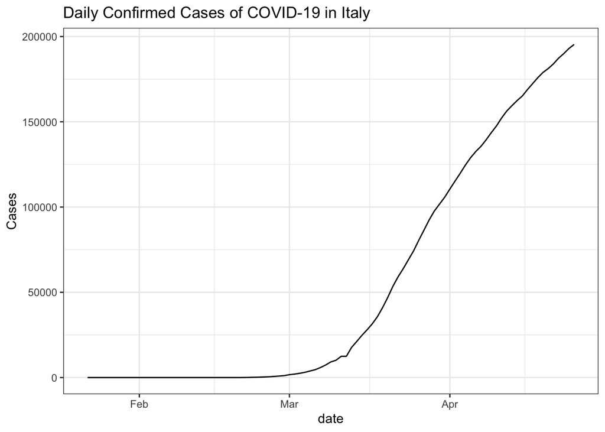

**Figure 1.** *COVID-19 Confirmed Cases in Italy.*

```r
ggplot(data, aes(x = date, y = C)) + geom_line() +
  ylab("Cases") + ggtitle("Daily Confirmed Cases of COVID-19 in Italy")
```

```r
caps = paste0("**Figure 1.** *COVID-19 Confirmed Cases in Italy.*")
```

```r
summary(data$C)
```

```
##    Min. 1st Qu.  Median    Mean 3rd Qu.    Max.
##       0       3    9172   54021  112908  195351
```

## 3. Design of POMP Model

### 3.1 Model Setup

Based on the description of the Centers for Disease Control and Prevention (CDC) website, symptoms may appear 2-14 days after exposure to the virus [1]. This period of latency in which people had exposed to the virus but not yet showing the symptoms should be included in the model. Hence, we consider using the S-E-I-R compartment modeling framework to fit the data.

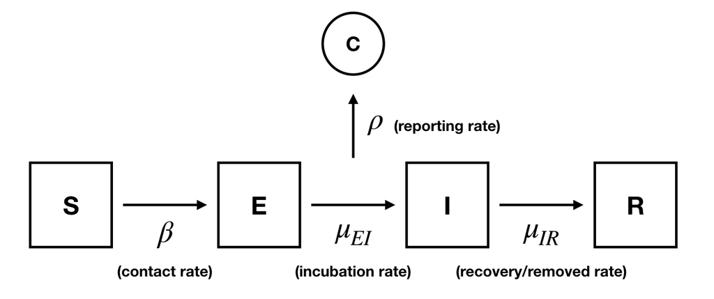

The four distinct stages represent: - $S$: the susceptible population, who never have COVID-19 before - $E$: the exposed population, who exposed to the infected individuals but do not show symptons - $I$: the infected population, including people who tested positive or not being tested - $R$: the recovered or removed (death) population

Next, we will define the parameters that we use to set up the model.

### 3.2 State Process

The state variables $S$, $E$, $I$, and $R$ are modeled as follows:

$$\begin{aligned}
&S(t+\delta) = S(t) - N_{SE}(\delta), \ where \ N_{SE} \sim Bin(S(t), 1 - exp(-\beta \frac{I(t)}{N}\delta)) \\
&E(t+\delta) = E(t) + N_{SE}(\delta) - N_{EI}(\delta), \ where \ N_{EI} \sim Bin(E(t), 1 - exp(-\mu_{EI} \delta)) \\
&I(t+\delta) = I(t) + N_{EI}(\delta) - N_{IR}(\delta), \ where \ N_{IR} \sim Bin(I(t), 1 - exp(-\mu_{IR} \delta)) \\
&R(t+\delta) = R(t) + N_{IR}(\delta)
\end{aligned}$$
In the above equations, the quantities of the form $N_{ij}$ indicate the number of individuals who moved from compartment $i$ to compartment $j$ in a time length of $\delta$. The Binomial distribution with exponential probabilities was chosen since it seems to fit the data better.

The parameter $\beta$, the contact rate, represents the rate of a susceptible moving to the exposed compartment when in contact with an infected individual. The parameter $N$ corresponds to the total population. The parameter $\mu_{EI}$ is the incubation rate, the rate at which exposed people become infectious and $\mu_{IR}$ is the recovery and removed rate.

## 4. Model Implementation

### 4.1 Model Setup in POMP

```r
# POMP model: ------------------------------------------------------------------
covid_statenames = c("S", "E", "I", "R")
covid_paramnames = c("Beta", "mu_EI", "rho", "mu_IR", "N", "eta", "k")
covid_obsnames = "C"

covid_dmeasure = "lik = dpois(C, rho*I + 1e-6, give_log);"

covid_rmeasure = "C = rnbinom(rho*I, k);"

covid_rprocess = "
double dN_SE = rbinom(S, 1-exp(-Beta*I/N*dt));
double dN_EI = rbinom(E, 1-exp(-mu_EI*dt));
double dN_IR = rbinom(I, 1-exp(-mu_IR*dt));
S -= dN_SE;
E += dN_SE - dN_EI;
I += dN_EI - dN_IR;
R += dN_IR;
"

covid_rinit = "
S = 2500;
E = 1;
I = 1;
R = 0;
"

covid <- pomp(data = data, times = "day", t0 = 0,
              rprocess = euler(step.fun = Csnippet(covid_rprocess), delta.t = 1/7),
              rmeasure = Csnippet(covid_rmeasure),
              dmeasure = Csnippet(covid_dmeasure),
              partrans = parameter_trans(
                log=c("Beta","mu_EI","mu_IR", "k", "rho")),
              obsnames = covid_obsnames,
              statenames = covid_statenames,
              paramnames = covid_paramnames,
              rinit = Csnippet(covid_rinit)
)
```

### 4.2 Simulations and Particle Filter

We first tried out multiple combinations of parameters to see which values seemed more plausible to the data. The red lines in Figure 2 shows the twenty simulations and the blue green line is the observed data. It appears that the set of parameters may possibly fit the data.

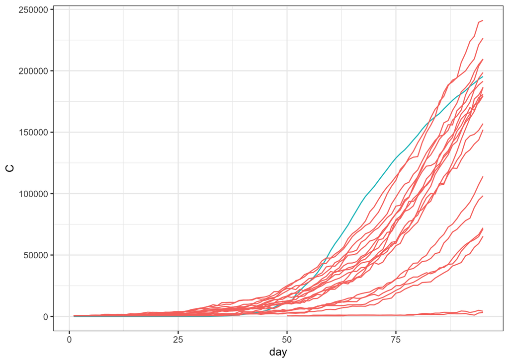

**Figure 2.** *Simulations for COVID-19 data.*

```r
sims = covid %>%
  simulate(params = c(Beta = 10, mu_EI = 0.01, mu_IR = .02, k = 0.42,
                      rho = 400, eta = 0.2, N = 30000),
           nsim = 20, format = "data.frame", include = TRUE)
ggplot(sims, aes(x = day, y = C, group = .id, color = .id=="data")) +
  geom_line() + guides(color=FALSE)
```

```r
caps = paste0("**Figure 2.** *Simulations for COVID-19 data.*")
```

Before using the IF2 algorithm [4] to carry out the likelihood maximization, we ran a few particle filters to obtain an estimate of Monte Carlo variability.

```r
# Run level: -------------------------------------------------------------------
run_level = 1
covid_Np =      switch(run_level, 100, 10000, 60000)
covid_Nmif =    switch(run_level,  10,   100,   300)
covid_Neval =   switch(run_level,  10,    10,    10)
covid_Nglobal = switch(run_level,  10,    10,   100)
covid_Nlocal =  switch(run_level,  20,    100,    20)

# Parallel Setup: --------------------------------------------------------------
library(foreach)
library(doParallel)
cores = 2
registerDoParallel(cores)
mcopts = list(set.seed = TRUE)

# pfilter: ---------------------------------------------------------------------
stew(file = sprintf("pf-%d.rda", run_level),{ t_pf = system.time(
  pf = foreach(i = 1:20, .packages = 'pomp') %dopar% try(
    pfilter(covid, Np = 500,
            params = c(Beta = 10, mu_EI = 0.01, mu_IR = .02, k = 0.42,
                       rho = 400, eta = 0.2, N = 30000),
            partrans = parameter_trans(
              log = c("Beta", "mu_EI", "mu_IR", "k", "rho")),
            dmeasure = Csnippet(covid_dmeasure),
            statenames = covid_statenames,
            paramnames = covid_paramnames)
    )
  ) }, seed = 1320290398, kind = "L'Ecuyer")
```

```r
load("pf-1.rda")
logmeanexp(sapply(pf, logLik), se = TRUE)
```

```
##                    se
## -2810.6017     2.4271
```

The average log likelihood estimate is $-2810.6017$ with $2.4271$ standard error.

### 4.3 IF2 Algorithm

Some issues arise when using the above optimization algorithm. For example, the particle filter gives us a stochastic estimate of the likelihood and the need of solving the constrained maximization problem. Given those issues, we will try another algorithm which is an iterated filtering algorithm (IF2) developed by Ionides et al [4] in 2015. The algorithm is a plug-and-play approach [5,6] for likelihood based inference in which the procedure theoretically converges toward the region of parameter space maximizing the maximum likelihood [7].

#### 4.3.1 Local MLE

We specified an interval for each parameter and ran a local search for the purpose of providing a better and more efficient global search later.

Note that we first set the run level equals to 1 and ran on the local computer, then changed it to 2 and ran on the great lakes cluster. Since the computing time increase linearly, it took around 7.3 hours using 36 cores to run on the great lakes cluster.

```r
# Local search: ----------------------------------------------------------------
run_level = 2

covid_box = rbind(
  Beta = c(10, 50),
  mu_EI = c(.01, .1),
  mu_IR = c(.01, .1),
  k = c(.1, 1),
  rho = c(.1, 5)
)
covid_fixed_params = c(eta = 0.5, N = 3800)
covid_rw.sd = 0.02
covid_cooling.fraction.50 = 0.5

stew(file = sprintf("box_eval-%d.rda", run_level),{
  t_local = system.time({
    covid_local = foreach(i = 1:covid_Nlocal, .options.multicore = mcopts,
                          .packages = 'pomp', .combine = c) %dopar% mif2(
                            covid,
                            params = c(
                              apply(covid_box,1, function(x) runif(1, x[1], x[2])),
                              covid_fixed_params),
                            cooling.fraction.50 = covid_cooling.fraction.50,
                            Nmif = covid_Nmif,
                            Np = covid_Np,
                            rw.sd = rw.sd(
                              Beta = covid_rw.sd,
                              mu_EI = covid_rw.sd,
                              mu_IR = covid_rw.sd,
                              k = covid_rw.sd,
                              rho = covid_rw.sd,
                              N = ivp(covid_rw.sd),
                              eta = ivp(covid_rw.sd)
                              )
                            )
    })
  }, seed = 900242058, kind = "L'Ecuyer")

# likelihood local
stew(file = sprintf("lik_local_eval-%d.rda", run_level),{
  t_local_eval = system.time({
    liks_local = foreach(i = 1:covid_Nlocal, .options.multicore = mcopts,
                         .packages = 'pomp',.combine = rbind) %dopar% {
                           evals = replicate(covid_Neval,logLik(
                               pfilter(covid, params = coef(covid_local[[i]]),
                                       Np = covid_Np)))
                           logmeanexp(evals, se=TRUE)
                           }
    })
  }, seed = 442141592, kind = "L'Ecuyer")
```

Figure 3 shows the pairpolt of selected parameters that used to adjust the parameter interval for global search.

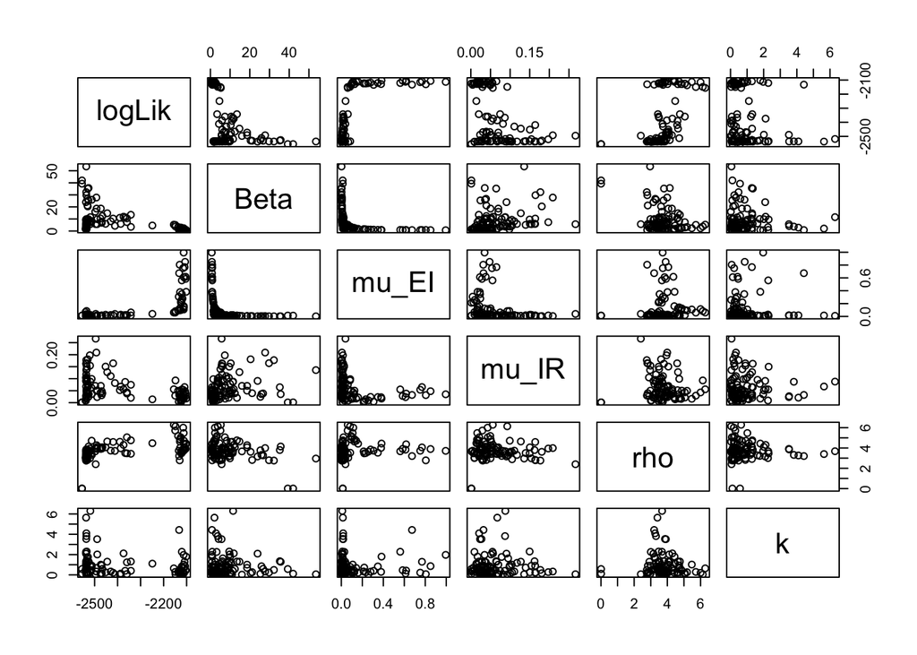

**Figure 3.** *Local MLE pairplot of selected parameters.*

```r
load("box_eval-2.rda")
load("lik_local_eval-2.rda")
results_local = data.frame(
  logLik = liks_local[,1],
  logLik_se = liks_local[,2], t(sapply(covid_local, coef))
  )

pairs(~logLik+Beta+mu_EI+mu_IR+rho+k, data = results_local)
```

```r
caps = paste0("**Figure 3.** *Local MLE pairplot of selected parameters.*")
```

#### 4.3.2 Global MLE

The global search is carried out based on the local search. It took 43.5 minutes for the maximization and 3.3 minutes for evaluations.

```r
#80: ---------------------------------------------------------------------------
stew(file = sprintf("g_box_eval-%d.rda", run_level),{
  t_global = system.time({
    covid_gloal = foreach(i = 1:covid_Nglobal, .options.multicore = mcopts,
                          .packages = 'pomp', .combine = c) %dopar% mif2(
                            covid_local[[1]],
                            params = c(
                              apply(covid_box,1,function(x) runif(1, x[1], x[2])),
                                    covid_fixed_params)
                            )
    })
  }, seed = 900242058, kind = "L'Ecuyer")

# likelihood eval at each point estimate
stew(file = sprintf("lik_global_eval-%d.rda", run_level),{
  t_global_eval = system.time({
    liks_global = foreach(i = 1:covid_Nglobal, .options.multicore = mcopts,
                          .packages = 'pomp', .combine = rbind) %dopar% {
                            evals = replicate(covid_Neval, logLik(
                              pfilter(covid,
                                      params = coef(covid_gloal[[i]]),
                                      Np = covid_Np)))
                            logmeanexp(evals, se = TRUE)
                            }
    })
  }, seed = 442141592, kind = "L'Ecuyer")
```

```r
load("g_box_eval-2.rda")
load("lik_global_eval-2.rda")
results_global = data.frame(
  logLik = liks_global[,1],
  logLik_se = liks_global[,2],
  t(sapply(covid_global, coef))
  )
summary(results_global$logLik, digits = 5)
```

```
##    Min. 1st Qu.  Median    Mean 3rd Qu.    Max.
##   -2536   -2526   -2481   -2400   -2334   -2118
```

The loglikelihood of 10 global evaluations on 10000 particle filters have a minumum of -2536 and a maximum of -2118.

## 5. Results and Model Diagnostics

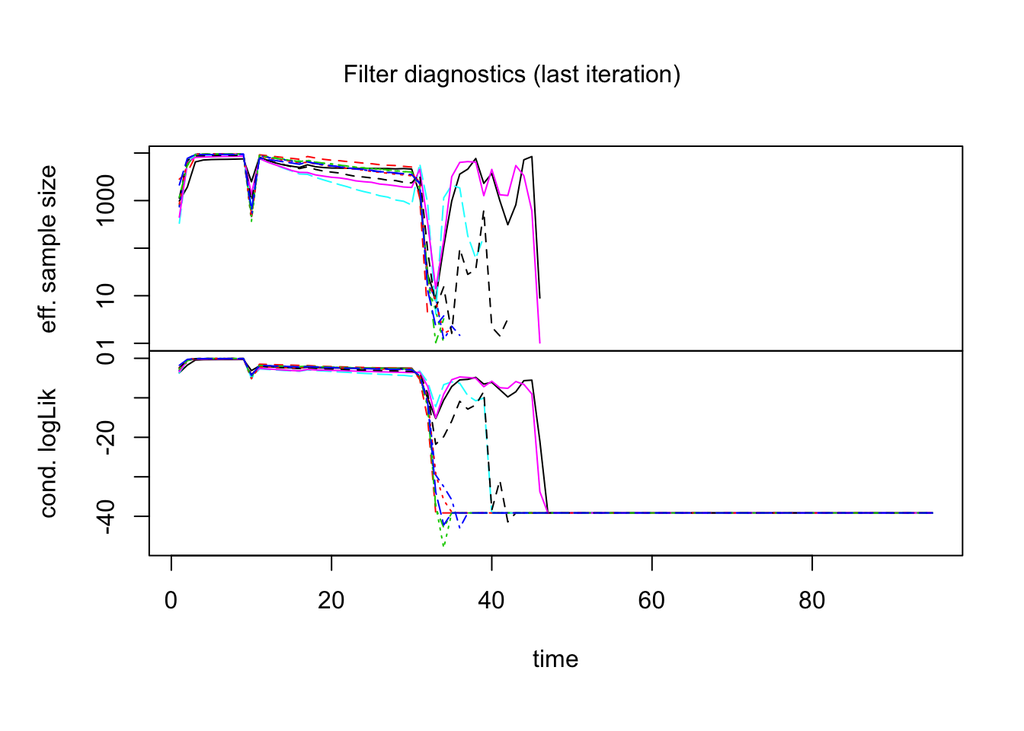

**Figure 5.** *Diagnostic plot of global MLE search and evaluations.*

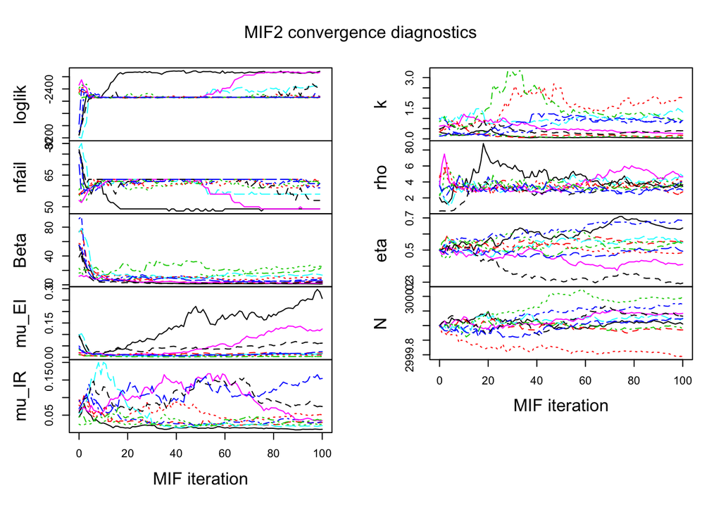

**Figure 5.** *Diagnostic plot of global MLE search and evaluations.*

```r
plot(covid_global)
```

```r
caps = paste0("**Figure 5.** *Diagnostic plot of global MLE search and evaluations.*")
```

## 7. Reference

[1] https://www.cdc.gov/coronavirus/2019-ncov/symptoms-testing/symptoms.html

[2] The Ebola Epidemic of 2014-2016: Sierra Leone https://ionides.github.io/531w18/final_project/33/final.html

[3] Simulation-based Inference for Epidemiological Dynamics https://kingaa.github.io/sbied/index.html

[4] Ionides, E. L., Nguyen, D., Atchad ́e, Y., Stoev, S. and King, A. A. (2015). Inference for dynamic and latent variable models via iterated, perturbed Bayes maps, Proceedings of the National Academy of Sciences of USA 112: 719–724.

[5] He, D., Ionides, E. L. and King, A. A. (2010). Plug-and-play inference for disease dynamics: Measles in large and small towns as a case study. Journal of the Royal Society Interface 7 271–283.

[6] Ionides, E. L., Bretó, C. and King, A. A. (2006). Inference for nonlinear dynamical systems.Proc. Natl. Acad. Sci. USA 103 18438–18443.

[7] Lecture notes 10-13, Stats 531, Winter 2020, Analysis of Time Series. From https://ionides.github.io/531w20/

[8] Wang, A case study on Smallpox transmission dynamic in California 1928-1935. From https://ionides.github.io/531w18/final_project/15/final.html

[9] What happens in case of a filtering failure? From https://github.com/kingaa/pomp/issues/36